# NextWordPrediction App

S Zaki.

1/13/2019

## NextWordPredict App

This App is built with Shiny from RStudio. The App takes textual input from the user in the form of a phrase or set of words and it predicts the next word.

#### User Inputs:

*Text Input:* The user can enter either words or a phrase into the text input box.

*Discount Value:* The user can choose either 0.5 (default) or 0.7. This discount is applied at all N-gram levels.

*Number of predictions:* The user can specify the number of predictions desired, between 3 (default) and 10 (these are plotted on the bar chart, and shown in the N-gram table).

*Update Button:* The user must click the “Click to Predict” button to see the predictions (and after any parameter changes).

## Output or Predictions:

When the user enters some words or a phrase in the text input box and clicks the “Click to Predict” button, the App displays:

1. *Top Prediction:*, the input text followed by the most probable predicted word (i.e., the highest probability word).
2. *Top 3 Predictions:*, the top 3 next words with the highest probability.
3. *Plot of top K predictions:* A bar plot displaying the user selected number of top ranked words (K) to report.
4. *N-gram table:* A table showing the N-grams and the Katz-backoff probability for each of the top K next words.

## Output Example:

[output not shown]

```
[1] "my"  "the" "you" "me"  "one" "her"
```

```
# A tibble: 6 x 5
# Groups:   word1, word2, word3 [1]
  word1 word2    word3 word4 kboQuadgram
  <chr> <chr>    <chr> <chr>       <dbl>
1 happy birthday to    my         0.233
2 happy birthday to    the        0.135
3 happy birthday to    you        0.0790
4 happy birthday to    me         0.0785
5 happy birthday to    one        0.0458
6 happy birthday to    her        0.0422
```

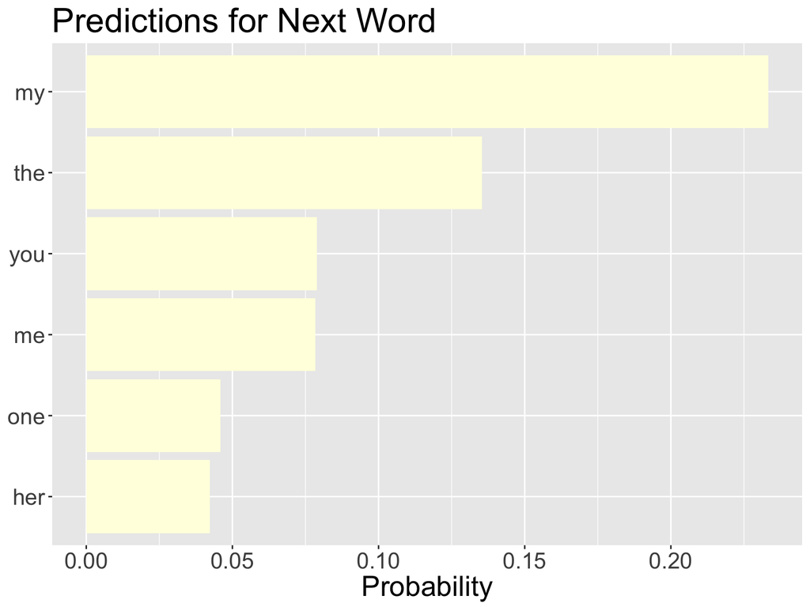

## Next Word Prediction Using Katz Back-off Model with Discount

This App uses the Katz back-off language model which uses a discounting method to make predictions for the **next word**, using **N-grams**. For training we used the entire text from the en_US blogs, news and twitter from the en_US locale from the corpus, HC Corpora: https://d396qusza40orc.cloudfront.net/dsscapstone/dataset/Coursera-SwiftKey.zip

1. Preprocessing the corpus: The text from the HC corpora files mentioned above was preprocessed and cleaned (e.g., removing numbers, converting to lower case, stripping of punctuation, and so on). Next, seen N-gram counts were generated using the tidytext package, for N=1, N=2, N=3, and N=4, that is for unigrams, bigrams, trigrams and quadgrams.
2. The N-grams (for N > 1) that occured just one time (had a count of 1) were dropped in order to reduce the memory used by the App.
3. The recursive Katz back-off model was implemented. It uses bigram, trigram and quadgram models to handle diffrent lengths of inputs efficiently. The bigram model takes a single word as input and generates all seen and unseen bigrams, the trigram model takes two words as input and generates all seen and unseen trigrams, and finally, the quadgram model takes three words as input and generates all the seen and unseen quadgrams. Each of the models uses the user-selected discount value, which is used to “discount” the frequencies of the seen N-grams, and to reallocate the discounted frequencies (used to generate the probabilty mass) to the unseen N-grams. Each of the models outputs the N-grams and their corresponding probabilities in rank order (from the higest to lowest probability).
4. Helper functions: Helper functions handle the input from text box, convert the input words or phrase to lowercase, strip off punctuation and white space and split it into individual words. Then, based on the number of words the function chooses one of the three N-gram models to get next word predictions. If the user enters only a single word the bigram model is used, if the user enters only two words the trigram model is used, and finally if a user enters three or more words the quadgram model is used.